# What makes a Movie have High Audience Ratings and High Profit? What is the Relatinship between a Movie’s High Audience Ratings and High Profit?

Marie Hasegawa - mhasegawa7045@floridapoly.edu

# Appendix

- Appendix
- Library of Packages
- Project Overview
- Exploratory Data Analysis
  - `Profitability` Column
  - `AudienceScore` Column
- Methods
  - `Profitability` vs. `AudienceScore` Grouped by `HighProfit`
  - `Profitability` and `AudienceScore` K-Means Clustering
    - Elbow Method and Silhouette method to determine optimal clusters
    - K-Means Clustering of k=2,3,4
  - `Profitability` Column
    - Decision Tree `Profitability`
      - With Categorical Variables
      - Removed Categorical Variables
    - Bagging
    - Random Forest
    - Random Forest with Boosting
    - Model Comparison High `Profitability`
  - `AudienceScore` Column
    - Decision Tree `Profitability`
      - With Categorical Variables
      - Removed Categorical Variables
    - Bagging
    - Random Forest
    - Random Forest with Boosting
    - Model Comparison High AudienceScore
- Conclusion

# Library of Packages

| **Variables** | **Description** |
| --- | --- |
| `Movie` | Title of movie |
| `LeadStudio` | Studio that released the movie |
| `RottenTomatoes` | Rotten Tomatoes rating (reviewers) |
| `AudienceScore` | Audience rating (via Rotten Tomatoes) |
| `Story` | General theme - one of 21 themes |
| `Genre` | Type of Movie: Action, Adventure, Animation, Comedy, Drama, Fantasy, Horror, Romance, or Thriller |
| `TheatersOpenWeek` | Number of screens for opening weekend |
| `BOAverageOpenWeek` | Average box office income per theater - opening weekend |
| `DomesticGross` | Gross income for domestic viewers (in millions) |
| `ForeignGross` | Gross income for foreign viewers (in millions) |
| `WorldGross` | Gross income for all viewers (in millions) |
| `Budget` | Production budget (in millions) |
| `Profitability` | WorldGross/Budget |
| `OpeningWeekend` | Opening weekend gross (in millions) |

```r
library(tidyverse)
library(ISLR)
library(caret)
```

```r
library(tidyverse)
#install.packages("skimr")
library(skimr)
library(rpart.plot)
library(pROC)
library(ggplot2)
#install.packages("factoextra")
library(factoextra)
#install.packages("gridExtra")
library(gridExtra)
movie <- read_csv("https://raw.githubusercontent.com/reisanar/datasets/master/HollywoodMovies.csv")
```

# Project Overview

The box office industry is one of the biggest global markets in the entertainment industry. According to IMDbPro, the industry has a yearly average box office revenue of around 11 to 14 million dollars and a yearly total gross of around 9 to 12 billion dollars. The project wants to determine what makes a Hollywood movie have a high `Profitability` and what makes it have a high `AudienceScore`, and how `Profitability` and `AudienceScore` correlate with each other. Movie studios would find this information resourceful since it could help them determine the best kind of movies that will lead to larger profits and more positive feedback on their movies for better publicity.

This will be done with EDA, K-means clustering, decision trees, bagging, boosting, and random forests that will help determine the pattern for high-earning and highly-rated movies. This project will be done in RStudio and RCloud with the dataset, `HollywoodMovies`, provided by Dr. Reinaldo Sanchez-Arias.

# Explatory Data Analysis

```r
movie<-movie %>%
  na.omit()
sample_n(movie, size=20)
```

| Movie | LeadStudio | RottenTomatoes | AudienceScore | Story | Genre | TheatersOpenWeek | OpeningWeekend | BOAvgOpenWeekend | DomesticGross | ForeignGross | WorldGross | Budget | Profitability | OpenProfit | Year |
| --- | --- | --- | --- | --- | --- | --- | --- | --- | --- | --- | --- | --- | --- | --- | --- |
| X-Men Origins: Wolverine | Fox | 37 | 72 | Revenge | Action | 4099 | 85.10 | 20751 | 179.90 | 193.20 | 373.100 | 150 | 248.73 | 56.73 | 2009 |
| My Soul to Take | Relativity Media | 9 | 29 | Monster Force | Horror | 2572 | 6.84 | 2660 | 14.74 | 6.23 | 20.971 | 25 | 83.88 | 27.36 | 2010 |
| Crazy, Stupid, Love | Warner Bros | 78 | 81 | Discovery | Romance | 3020 | 19.10 | 6326 | 84.35 | 58.50 | 142.850 | 50 | 285.70 | 38.20 | 2011 |
| Angels & Demons | Sony | 36 | 65 | The Riddle | Mystery | 3527 | 46.20 | 13100 | 133.40 | 352.60 | 485.900 | 150 | 323.93 | 30.80 | 2009 |
| Leap Year | Universal | 21 | 49 | Love | Comedy | 2511 | 9.20 | 3665 | 25.92 | 6.69 | 32.608 | 19 | 171.62 | 48.42 | 2010 |
| Changeling | Independent | 62 | 84 | quest | Drama | 1850 | 9.40 | 5055 | 35.74 | 77.28 | 113.020 | 55 | 205.49 | 17.09 | 2008 |
| Pride & Glory | Warner Bros | 34 | 54 | Temptation | Crime | 2585 | 6.26 | 2423 | 15.74 | 15.41 | 31.150 | 30 | 103.82 | 20.87 | 2008 |
| Up in the Air | Paramount | 90 | 76 | Maturation | Drama | 1895 | 11.20 | 5947 | 83.82 | 116.38 | 200.200 | 25 | 800.81 | 44.80 | 2009 |
| Drive Angry | Independent | 45 | 38 | Rescue | Action | 2290 | 5.19 | 2265 | 10.72 | 18.21 | 28.930 | 45 | 64.29 | 11.53 | 2011 |
| The Three Musketeers | Independent | 24 | 48 | Rivalry | Action | 3017 | 8.67 | 2875 | 20.37 | 111.90 | 132.270 | 75 | 176.37 | 11.56 | 2011 |

[output cut: 10 more lines]

```r
movie %>%
  filter(Profitability>=400)
```

| Movie | LeadStudio | RottenTomatoes | AudienceScore | Story | Genre | TheatersOpenWeek | OpeningWeekend | BOAvgOpenWeekend | DomesticGross | ForeignGross | WorldGross | Budget | Profitability | OpenProfit | Year |
| --- | --- | --- | --- | --- | --- | --- | --- | --- | --- | --- | --- | --- | --- | --- | --- |
| Shrek the Third | Paramount | 42 | 57 | Quest | Animation | 4122 | 121.600 | 29507 | 322.72 | 476.24 | 798.960 | 160.0 | 499.35 | 76.00 | 2007 |
| Transformers | Paramount | 57 | 89 | Monster Force | Action | 4011 | 70.500 | 17577 | 319.25 | 390.46 | 709.710 | 150.0 | 473.14 | 47.00 | 2007 |
| Harry Potter and the Order of the Phoenix | Warner Bros | 78 | 82 | Quest | Adventure | 4285 | 77.100 | 17998 | 292.00 | 647.88 | 939.890 | 150.0 | 626.59 | 51.40 | 2007 |
| The Bourne Ultimatum | Universal | 93 | 91 | Pursuit | Thriller | 3660 | 69.300 | 18929 | 227.47 | 215.35 | 442.820 | 110.0 | 402.57 | 63.00 | 2007 |
| Alvin and the Chipmunks | Fox | 26 | 73 | Comedy | Animation | 3475 | 44.300 | 12750 | 217.33 | 144.01 | 361.340 | 70.0 | 516.19 | 63.29 | 2007 |
| 300 | Warner Bros | 60 | 90 | Sacrifice | Action | 3103 | 70.900 | 22844 | 210.61 | 245.45 | 456.070 | 65.0 | 701.64 | 109.08 | 2007 |
| Ratatouille | Disney | 97 | 84 | Transformation | Animation | 3940 | 47.000 | 11935 | 206.45 | 417.28 | 623.720 | 150.0 | 415.81 | 31.33 | 2007 |
| The Simpsons Movie | Fox | 90 | 78 | Maturation | Comedy | 3922 | 74.000 | 18877 | 183.14 | 343.94 | 527.070 | 75.0 | 702.76 | 98.67 | 2007 |
| Knocked Up | Universal | 91 | 83 | Love | Comedy | 2871 | 30.700 | 10690 | 148.77 | 70.31 | 219.080 | 33.0 | 663.86 | 93.03 | 2007 |
| Juno | Fox | 94 | 89 | Maturation | Comedy | 1019 | 10.600 | 10436 | 143.50 | 87.92 | 231.410 | 7.5 | 3085.48 | 141.33 | 2007 |

[output cut: 137 more lines]

The movie(`HollywoodMovies`) dataset originally had many NA values in all columns, which needed to be removed. The code above is used to remove NA values with `na.omit()` since it needs to be removed in order to train the code and create decision and random trees.

## `Profitability` Column

```r
summary(movie$Profitability)
```

```
##    Min. 1st Qu.  Median    Mean 3rd Qu.    Max.
##   18.17  151.52  253.64  356.04  397.08 6694.40
```

The variable, `Profitability`, in the dataset is the division between `WorldGross` and `Budget` in millions. The variables is used to determine if the movie made a huge profit beween `WorldGross` and `Budget` in millions. The variable, `Profitability`, will be used in this section to see what factors affect `Profitability`of a movie and how highly-profited movies and lowly profited movies differ from each other. The variable, `HighProfit`, will be mutated from the variable, `Profitability`, in order to differ between high-profited movies and low-profited movies. Based on the summarization shown above, the project will define the variable,`HighProfit`, to determine a movie is highly-profitable if `Profitability` has a value of 400 or more, since the mean is 356.04 and the `third-quarter` is 397.08. The `HighProfit` variable can not be in the thousands like in the `max value` of 6694.40, since those values are considered an outlier becuase there are too few points to consider it.

```r
raw_A<-ggplot(data=movie) +
  geom_histogram(aes(x=Profitability)) +
  labs(title="Bar Chart of Profitability")
```

```r
rawB_Prof<-ggplot(data=movie) +
  geom_histogram(aes(x=Profitability)) +
  xlim(0,2000) +
  labs(title="Bar Chart of Profitability Removed Outliers")
```

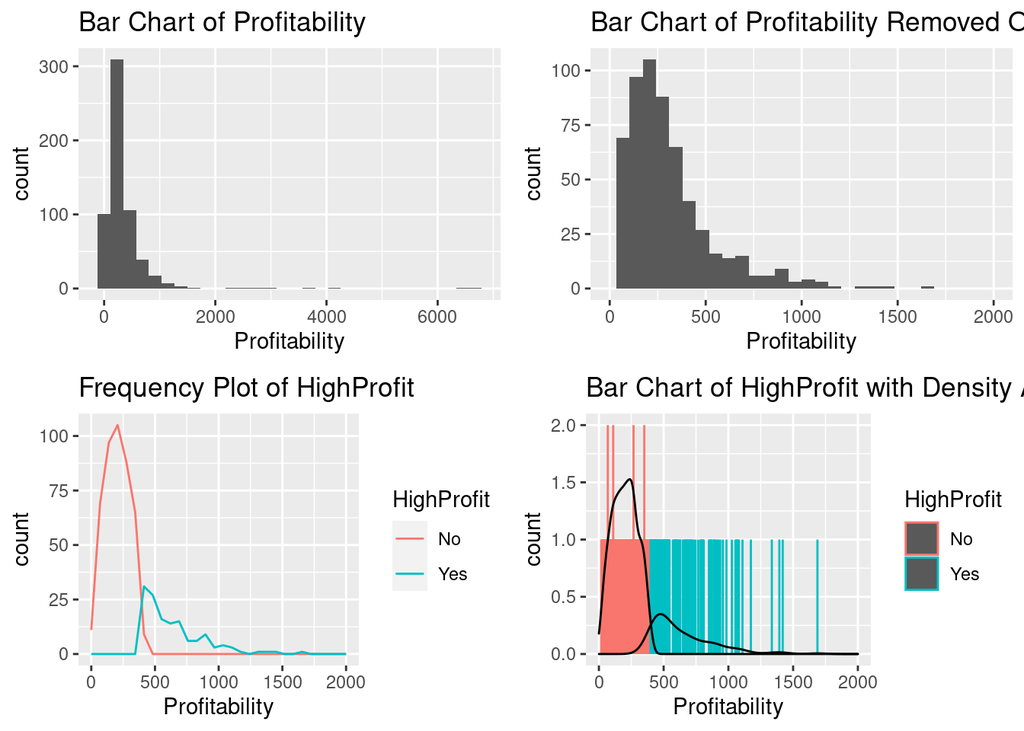

```r
movieB<-movie %>%
  mutate(HighProfit=ifelse(movie$Profitability >= 400, "Yes", "No"))

mBHP_F<-movieB %>%
  ggplot(aes(Profitability, colour = HighProfit)) +
  geom_freqpoly() +
  xlim(0,2000) +
  labs(title="Frequency Plot of HighProfit")

mBHP_D<-movieB %>%
  ggplot(aes(Profitability, colour = HighProfit)) +
  geom_bar() +
  geom_density(aes(y = ..count.., group=HighProfit),color="black") +
  xlim(0,2000) +
  labs(title="Bar Chart of HighProfit with Density Analysis")

grid.arrange(raw_A,rawB_Prof,mBHP_F, mBHP_D)
```

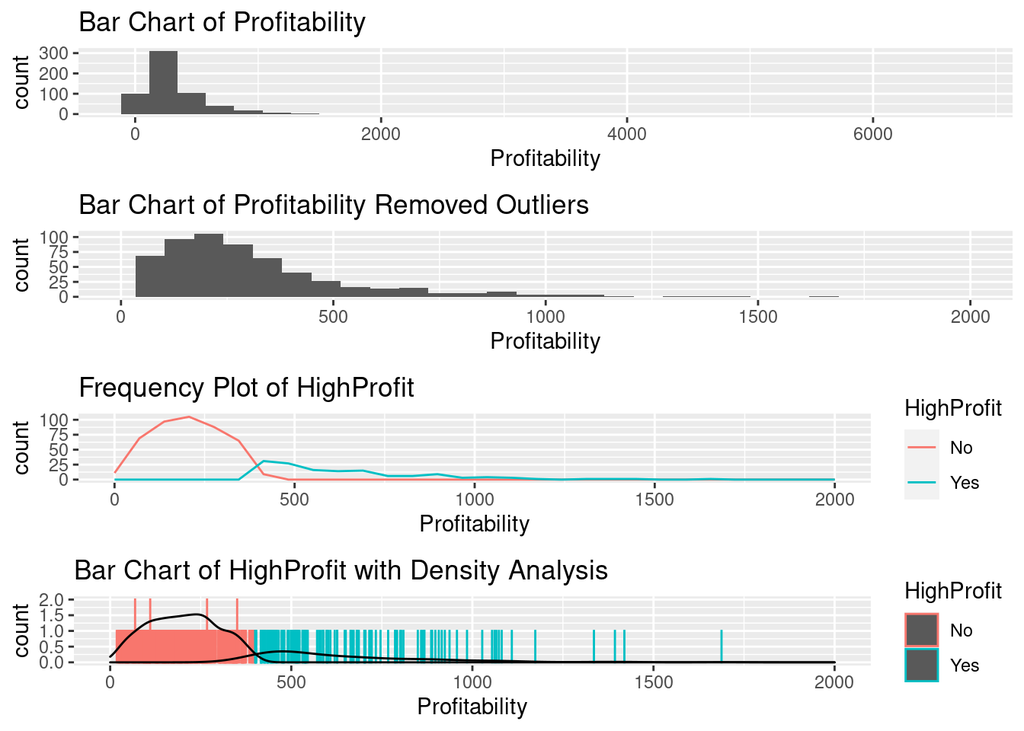

```r
grid.arrange(raw_A,rawB_Prof,mBHP_F, mBHP_D, ncol=1)
```

```r
#aes(group=HighProfit),method="lm",color="black", size=0.3
```

As you can see in the histogram, `Bar Chart of Profitibility`, `Profitability` accumulates mostly in the range of `~0 to ~2000 and has outliers in the range of`~2000 to 6500. Due to this, the outliers will be omitted for the EDA and in the `Bar Chart of Profitibility`, so it can be easier to analyze the relationship between high-profited movies and low-profited movies. This can be seen in the graph shown below with x (`Profitability`) limited between 0 to 2000.

The `Frequency Plot of HighProfit` and the `Bar Chart of HighProfit with Density Analysis` shows that low-profited movies occur more frequently compared to high-profited movies. The reason might be that a movie’s success is dependent on the movie’s advertisement, availability globally, and its name/branding recognition.

For example, the movie, **Shrek the Third** is an extremely profitable movie of 499.35 but it is a sequel of the other Shrek film and is based on a very popular icon, Shrek, which could contribute a film’s `Profitability` that is not shown on the graph.

## `AudienceScore` Column

```r
summary(movie$AudienceScore)
```

```
##    Min. 1st Qu.  Median    Mean 3rd Qu.    Max.
##   19.00   48.00   60.00   60.28   73.00   96.00
```

The variable, `AudienceScore`, in the dataset is a collection of the Rotten Tomatoes ratings from the audience. The variable `HighAud` is used to determine if the movie made a good impression on the Rotten Tomatoes audience. The variable, `AudienceScore`, will be used in this project to see what factors affect `AudienceScore` ratings of a movie and how highly-rated movies based on audience reviews differ from lowly-rated films. The variable, `HighAud`, will be mutated from the variable, `AudienceScore`, in order to differentiate between highly-rated by-audience movies and low-rated movies. Based on the summarization shown above, the project will define the variable, `HighAud`, to determine a movie is highly-rated by critics if `AudienceScore` has a value of 70 or more since the `third-quarter` is 73.

```r
raw_B<-ggplot(data=movie) +
  geom_histogram(aes(x=AudienceScore)) +
  labs(title="Bar Chart of HighAud ")
```

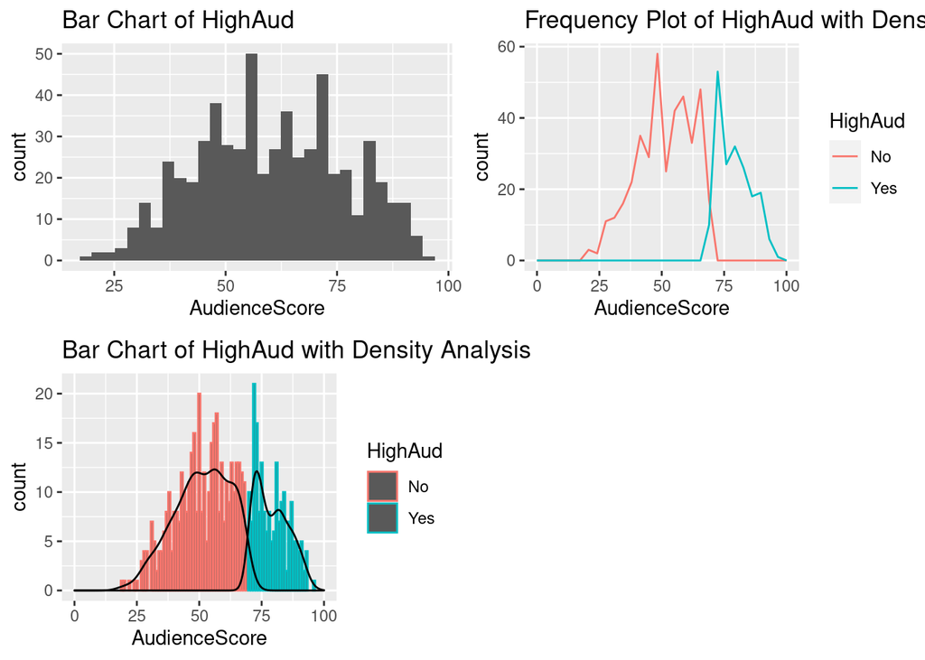

```r
movieB<-movieB %>%
  mutate(HighAud=ifelse(movie$AudienceScore >= 70, "Yes", "No"))

Freq_mB<-movieB %>%
  ggplot(aes(AudienceScore, colour = HighAud)) +
  geom_freqpoly() +
  xlim(0,100) +
  labs(title="Frequency Plot of HighAud with Density Analysis")

Bar_mB<-
  movieB %>%
  ggplot(aes(AudienceScore, colour = HighAud)) +
  geom_bar() +
 geom_density(aes(y = ..count.., group=HighAud),color="black") +
  xlim(0,100)+
  labs(title="Bar Chart of HighAud with Density Analysis")

grid.arrange(raw_B,Freq_mB, Bar_mB, nrow = 2)
```

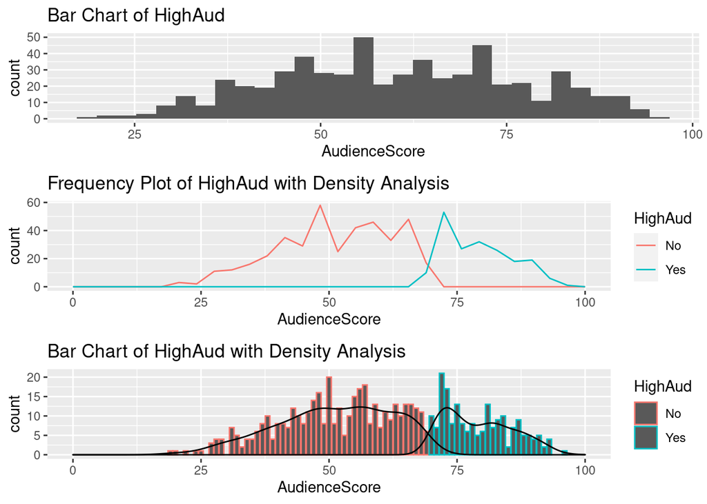

```r
grid.arrange(raw_B,Freq_mB, Bar_mB)
```

There is barely any difference between low-rated movies and highly-rated movies in the `Bar Chart of HighAud with Density Analysis`. There is a ~5-count difference between the highly rated movies and lowly rated movies in the `Frequency Plot of HighAud`. However, the density in the `Bar Chart of HighAud with Density Analysis` shows that low-rated movies and highly-rated movies peak at the same `count` level of 12. The `Frequency Plot of HighAud` and the `Bar Chart of HighAud with Density Analysis` shows that low-audience rated movies occur more frequently compared to high-profited movies.

# Methods

## `Profitability` vs. `AudienceScore` Grouped by `HighProfit`

The purpose of this section is to see the relationship between `Profitability` and `AudienceScore` by clustering the points with `HighProfit`.

```r
movieB
```

| Movie | LeadStudio | RottenTomatoes | AudienceScore | Story | Genre | TheatersOpenWeek | OpeningWeekend | BOAvgOpenWeekend | DomesticGross | ForeignGross | WorldGross | Budget | Profitability | OpenProfit | Year | HighProfit | HighAud |
| --- | --- | --- | --- | --- | --- | --- | --- | --- | --- | --- | --- | --- | --- | --- | --- | --- | --- |
| Spider-Man 3 | Sony | 61 | 54 | Metamorphosis | Action | 4252 | 151.100 | 35540 | 336.530 | 554.340 | 890.870 | 258.0 | 345.30 | 58.57 | 2007 | No | No |
| Shrek the Third | Paramount | 42 | 57 | Quest | Animation | 4122 | 121.600 | 29507 | 322.720 | 476.240 | 798.960 | 160.0 | 499.35 | 76.00 | 2007 | Yes | No |
| Transformers | Paramount | 57 | 89 | Monster Force | Action | 4011 | 70.500 | 17577 | 319.250 | 390.460 | 709.710 | 150.0 | 473.14 | 47.00 | 2007 | Yes | Yes |
| Pirates of the Caribbean: At World's End | Disney | 45 | 74 | Rescue | Action | 4362 | 114.700 | 26302 | 309.420 | 654.000 | 963.420 | 300.0 | 321.14 | 38.23 | 2007 | No | Yes |
| Harry Potter and the Order of the Phoenix | Warner Bros | 78 | 82 | Quest | Adventure | 4285 | 77.100 | 17998 | 292.000 | 647.880 | 939.890 | 150.0 | 626.59 | 51.40 | 2007 | Yes | Yes |
| I Am Legend | Warner Bros | 69 | 69 | Quest | Thriller | 3606 | 77.200 | 21411 | 256.390 | 328.960 | 585.350 | 150.0 | 390.23 | 51.47 | 2007 | No | No |
| The Bourne Ultimatum | Universal | 93 | 91 | Pursuit | Thriller | 3660 | 69.300 | 18929 | 227.470 | 215.350 | 442.820 | 110.0 | 402.57 | 63.00 | 2007 | Yes | Yes |
| National Treasure: Book of Secrets | Disney | 31 | 72 | The Riddle | Thriller | 3832 | 44.800 | 11686 | 219.960 | 237.400 | 457.360 | 130.0 | 351.82 | 34.46 | 2007 | No | Yes |
| Alvin and the Chipmunks | Fox | 26 | 73 | Comedy | Animation | 3475 | 44.300 | 12750 | 217.330 | 144.010 | 361.340 | 70.0 | 516.19 | 63.29 | 2007 | Yes | Yes |
| 300 | Warner Bros | 60 | 90 | Sacrifice | Action | 3103 | 70.900 | 22844 | 210.610 | 245.450 | 456.070 | 65.0 | 701.64 | 109.08 | 2007 | Yes | Yes |

[output cut: 581 more lines]

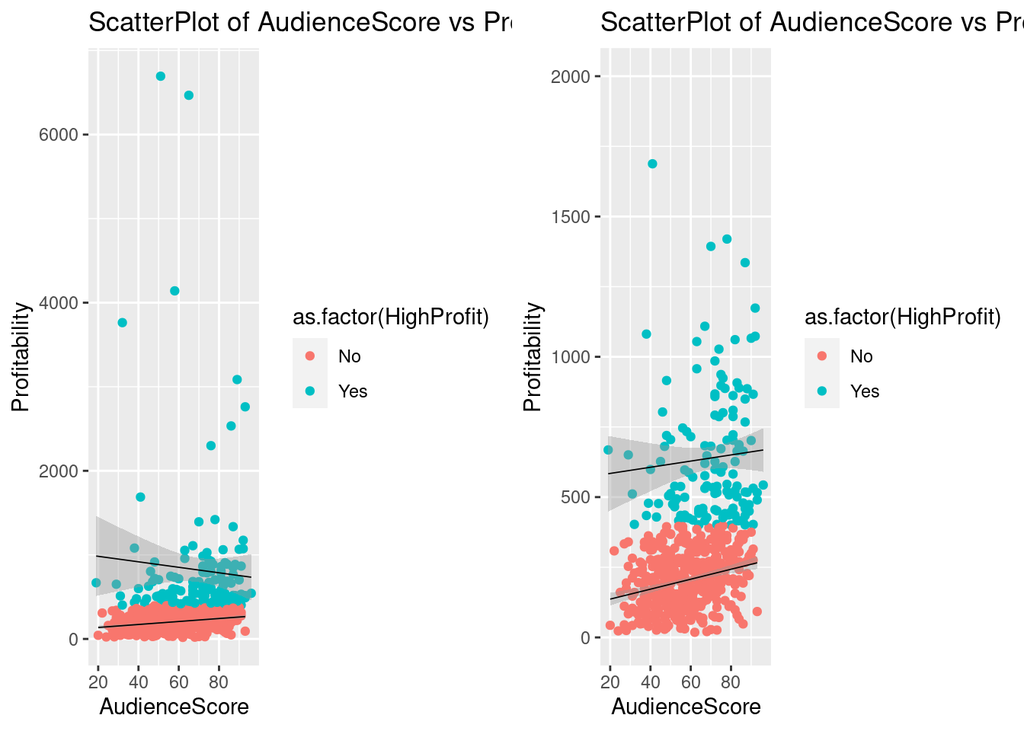

```r
movieBclusHighProf<-movieB %>%
ggplot(aes(x = AudienceScore, y = Profitability, color = as.factor(HighProfit))) +
  geom_point() +
  geom_smooth(aes(group=HighProfit),method="lm",color="black", size=0.3)+
  labs(title = "ScatterPlot of AudienceScore vs Profitability with Linear Method")

movieBclusHighProf_2000<-movieB %>%
ggplot(aes(x = AudienceScore, y = Profitability, color = as.factor(HighProfit))) +
  geom_point() +
  geom_smooth(aes(group=HighProfit),method="lm",color="black", size=0.3)+
  ylim(0,2000)+
  labs(title = "ScatterPlot of AudienceScore vs Profitability with Linear Method without Outliers")
grid.arrange(movieBclusHighProf,movieBclusHighProf_2000, nrow = 1)
```

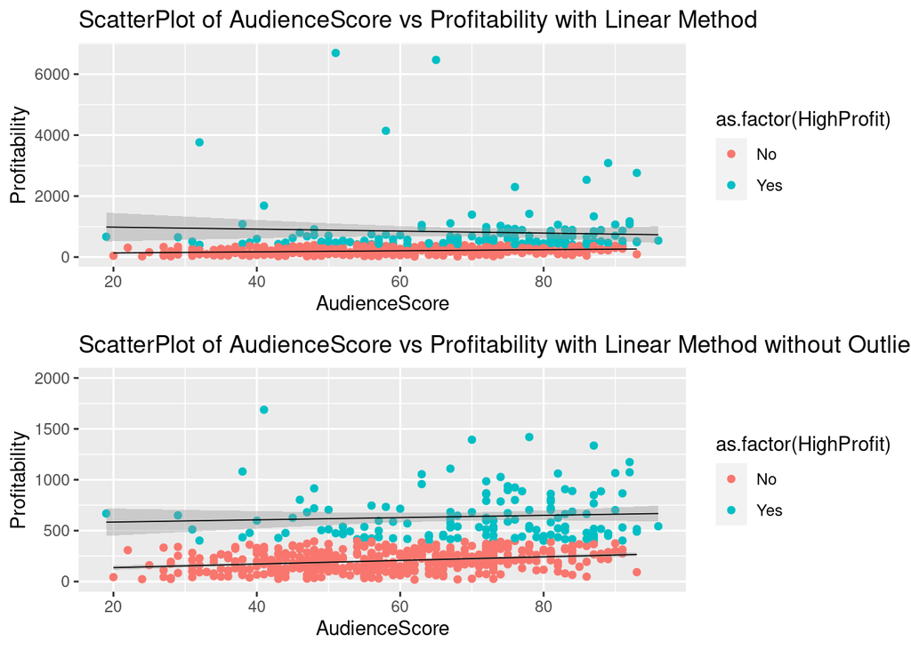

```r
grid.arrange(movieBclusHighProf,movieBclusHighProf_2000)
```

The `ggplots` shown above shows the relationship between `AudienceScore` and `Profitability` that is clustered with `HighProfit`.

It shows that the `ScatterPlot of AudienceScore vs Profitability with Linear Method without Outliers` for lowly profited movies have a positive slope, while highly-profited movies have also a positive slope. This shows that as the `AudienceScore` for lowly profited increases the `Profitability` increases and for highly-profited increases then there is an increase in `Profitability`.

### Elbow Method and Silhouette method to determinine optimal clusters

```r
myvars<-c("RottenTomatoes", "AudienceScore", "TheatersOpenWeek", "DomesticGross", "ForeignGross","WorldGross","Budget","Profitability","OpeningWeekend","BOAvgOpenWeekend")
```

The code above is used to remove the categorical variables, `Movie` and `LeadStudio`, so the dataset can be used for kmeans, since kmeans does not respond to datasets with columns being a collection of string values.

```r
movieB<-movieB[myvars] %>%
  na.omit()

movieB<-data.frame(movieB)
```

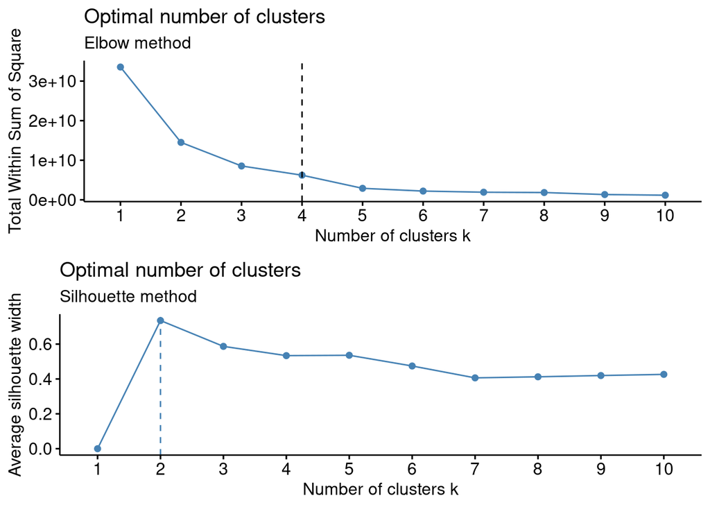

```r
set.seed(123)
# Elbow method
ELBmovie<-fviz_nbclust(movieB, kmeans, method = "wss") +
    geom_vline(xintercept = 4, linetype = 2)+
  labs(subtitle = "Elbow method")

# Silhouette method
SLmovie<-fviz_nbclust(movieB, kmeans, method = "silhouette")+
  labs(subtitle = "Silhouette method")
set.seed(123)
grid.arrange(ELBmovie, SLmovie, nrow = 2)
```

In order to find the most optimal number clusters to use for k-means clustering. The `elbow method` and the `silhouette method` will be used to determine the best number of clusters. The `elbow method` computes k-means clustering for every different value of k. Then for every k value has the total within-cluster sum of squares (wss) calculated. Based on this, the best cluster for the `elbow method` would be 4. The `silhouette method` measures the quality of a cluster which determines how well each object lies within their cluster. Based on this and the `Optimal number of clusters Silhouette Method`, the most optimal number of clusters is 2. The project will choose the k values 2, 3, and 4 for K-means clustering since they are the most optimal k-values based on the `elbow method` and the `silhouette method`.

### K-Means Clustering of k=2,3,4

```r
myvars<-c("RottenTomatoes", "AudienceScore", "TheatersOpenWeek", "DomesticGross", "ForeignGross","WorldGross","Budget","Profitability","OpeningWeekend","BOAvgOpenWeekend")
```

The code above is used to remove the categorical variables, `Movie` and `LeadStudio`, so the dataset can be used for kmeans, since kmeans does not respond to datasets with columns being a collection of string values.

```r
movieB<-movieB[myvars] %>%
  na.omit()

movieB<-data.frame(movieB)
```

```r
movieB_clust<-movieB[,5]
mcls2<-kmeans(x=movieB_clust[!is.na(movieB_clust)], centers=2)
mcls3<-kmeans(x=movieB_clust[!is.na(movieB_clust)], centers=3)
mcls4<-kmeans(x=movieB_clust[!is.na(movieB_clust)], centers=4)
```

```r
mcls2
```

```
## K-means clustering with 2 clusters of sizes 58, 533
##
## Cluster means:
##        [,1]
## 1 471.00779
## 2  57.84004
##
## Clustering vector:
##   [1] 1 1 1 1 1 1 2 2 2 2 1 1 2 2 2 2 2 2 2 2 2 2 2 2 2 2 2 2 2 2 2 2 2 2 2 1 2
##  [38] 2 2 2 2 2 2 2 2 2 2 2 2 2 2 2 2 2 2 2 2 2 2 2 2 2 2 2 2 2 2 2 2 2 2 2 2 2
##  [75] 2 2 2 2 2 2 2 2 2 2 1 1 1 1 1 1 1 2 1 2 2 1 1 2 2 2 2 2 2 2 1 2 2 2 2 2 2
## [112] 2 2 2 2 2 2 2 2 2 2 2 2 2 2 2 2 2 2 2 2 2 2 2 2 2 2 2 2 2 2 2 2 2 2 2 2 2
## [149] 2 2 2 2 2 2 2 2 2 2 2 2 2 2 2 2 2 2 2 2 2 2 2 2 2 2 2 2 2 2 2 2 2 2 2 2 2
## [186] 2 2 2 2 2 2 2 2 2 2 2 2 2 2 2 2 2 2 2 2 2 2 2 2 2 2 2 2 1 1 1 1 1 2 2 2 2
## [223] 1 2 1 2 2 1 2 2 2 2 2 2 1 2 2 2 2 2 2 2 2 2 2 2 2 2 2 2 2 2 2 2 2 2 2 2 2
## [260] 2 2 2 2 2 2 2 2 2 2 2 2 2 2 2 2 2 2 2 2 2 2 2 2 2 2 2 2 2 2 2 2 2 2 2 2 2
## [297] 2 2 2 2 2 2 2 2 2 2 2 2 2 2 2 2 2 2 2 2 2 2 2 2 2 2 2 2 2 2 2 2 2 2 2 2 2
## [334] 2 2 2 2 2 2 2 2 2 2 2 2 2 2 2 2 2 1 2 2 2 2 2 2 2 2 2 2 1 2 2 2 2 2 2 2 2
## [371] 1 2 2 2 2 2 2 2 2 2 2 2 2 2 2 2 2 2 1 2 1 1 1 2 2 2 2 2 2 2 2 2 2 2 2 2 2
## [408] 2 2 2 2 2 2 2 2 2 2 2 2 2 2 2 2 2 2 2 2 1 2 2 2 2 2 2 1 2 2 2 2 2 1 2 2 2
## [445] 2 2 2 1 2 2 2 2 2 2 2 2 2 2 2 2 1 2 2 1 2 2 2 2 2 2 2 2 2 2 2 2 2 2 2 2 2
## [482] 2 2 2 2 2 2 1 2 2 2 2 2 2 2 2 2 2 2 1 2 2 2 2 2 2 2 2 2 1 2 2 2 2 2 2 2 2
## [519] 2 2 2 1 2 2 2 2 1 2 2 2 2 2 2 2 2 2 1 2 1 2 2 2 1 1 2 2 2 2 1 2 2 2 2 2 2
## [556] 1 2 2 2 2 2 2 2 2 2 2 1 2 2 2 2 2 2 2 2 1 2 2 2 1 2 1 1 2 2 2 2 2 2 2 2
##
## Within cluster sum of squares by cluster:
## [1] 3761951 1794220
##  (between_SS / total_SS =  61.6 %)
##
## Available components:
##
## [1] "cluster"      "centers"      "totss"        "withinss"     "tot.withinss"
## [6] "betweenss"    "size"         "iter"         "ifault"
```

`mcls2` is a k-means clustering with 2 clusters or centers of size 58 and 533. The cluster mean of 1 is 471.00779 and the cluster mean of 2 is 57.84004. The sum of squares in cluster 1 is 3761951 and in cluster 2 is 1794220.

```r
mcls3
```

```
## K-means clustering with 3 clusters of sizes 84, 13, 494
##
## Cluster means:
##        [,1]
## 1 298.49229
## 2 795.62923
## 3  46.01348
##
## Clustering vector:
##   [1] 2 1 1 2 2 1 1 1 3 1 1 1 3 3 3 3 1 3 3 1 3 3 3 3 3 1 3 3 3 3 3 3 3 3 3 1 3
##  [38] 3 3 3 3 3 3 3 3 3 3 3 3 3 3 3 3 3 3 3 3 3 3 3 3 3 3 3 3 3 3 3 3 3 3 3 3 3
##  [75] 3 3 3 3 3 3 3 3 3 3 1 1 1 1 1 1 1 1 1 3 1 1 1 3 1 3 3 3 1 3 1 3 3 3 3 3 1
## [112] 3 3 3 3 3 3 3 3 1 3 3 3 3 3 3 3 3 3 3 3 3 3 3 3 3 3 3 3 3 3 3 3 3 3 3 3 3
## [149] 3 3 3 3 3 3 3 3 3 3 3 3 3 3 3 3 3 3 3 3 3 3 3 3 3 3 3 3 3 3 3 3 3 3 3 3 3
## [186] 3 3 3 3 3 3 3 3 3 3 3 3 3 3 3 3 3 3 3 3 3 3 3 3 3 3 3 3 2 1 2 1 1 1 3 3 1
## [223] 1 1 2 1 1 2 3 1 3 3 3 1 1 1 3 1 1 3 3 3 3 3 3 3 3 3 3 3 3 3 3 3 3 3 1 3 3
## [260] 3 3 3 3 3 3 3 3 3 3 3 3 3 3 3 3 3 3 3 3 3 3 3 3 3 3 3 3 3 3 3 3 3 3 3 3 3
## [297] 3 3 3 3 3 3 3 3 3 3 3 3 3 3 3 3 3 3 3 3 3 3 3 3 3 3 3 3 3 3 3 3 3 3 3 3 3
## [334] 3 3 3 3 3 3 3 3 3 3 3 3 3 3 3 3 3 2 3 3 1 3 3 3 3 3 3 3 1 3 3 3 3 3 3 3 3
## [371] 1 3 3 3 3 3 3 3 3 3 3 3 3 3 3 3 3 1 2 3 1 1 1 3 3 3 3 3 1 3 3 3 3 3 3 3 3
## [408] 3 3 1 3 3 3 3 3 3 1 3 3 3 1 1 1 3 3 1 3 1 3 3 3 3 3 3 1 3 3 3 3 3 1 3 3 3
## [445] 3 1 3 1 1 3 3 3 3 3 3 3 3 3 1 3 1 3 3 2 1 3 3 3 3 3 3 3 3 3 3 3 3 3 3 3 3
## [482] 3 3 3 3 3 1 1 3 3 3 3 3 3 3 3 3 3 3 1 3 3 3 3 3 3 3 3 3 2 3 3 3 3 3 3 3 3
## [519] 3 3 3 1 3 3 3 3 1 3 3 3 3 3 3 3 3 3 2 3 1 3 1 3 1 1 3 3 3 3 1 3 3 3 3 3 3
## [556] 1 3 3 3 3 3 3 3 3 3 3 1 3 3 3 3 3 3 3 3 1 3 3 3 1 3 2 1 3 3 3 3 3 1 3 3
##
## Within cluster sum of squares by cluster:
## [1]  864482.1 1754172.2  828400.7
##  (between_SS / total_SS =  76.2 %)
##
## Available components:
##
## [1] "cluster"      "centers"      "totss"        "withinss"     "tot.withinss"
## [6] "betweenss"    "size"         "iter"         "ifault"
```

`mcls3` is a k-means clustering with 3 clusters or centers of size 84, 13, and 494. The cluster mean of 1 is 298.49229, the cluster mean of 2 is 795.62923, and the cluster mean 3 of 46.01348. The sum of squares in cluster 1 is 864482.1, cluster 2 is 1754172.2, and cluster 3 is 828400.7.

```r
mcls4
```

```
## K-means clustering with 4 clusters of sizes 115, 420, 45, 11
##
## Cluster means:
##        [,1]
## 1 153.82391
## 2  32.55724
## 3 391.06960
## 4 835.02455
##
## Clustering vector:
##   [1] 3 3 3 4 4 3 1 1 1 1 3 3 2 2 2 1 1 1 1 1 1 2 2 2 2 1 1 2 2 2 2 2 1 2 1 3 2
##  [38] 2 2 2 2 2 1 2 1 2 2 2 2 2 2 2 2 2 1 2 2 2 2 2 2 2 2 2 2 2 2 2 2 2 2 2 2 2
##  [75] 2 2 2 2 2 2 2 2 2 2 3 1 3 3 3 3 3 1 3 1 1 3 3 1 1 1 2 1 1 1 3 1 2 2 1 1 1
## [112] 2 1 2 1 2 1 1 2 1 2 2 1 2 2 2 1 2 1 2 1 2 2 2 2 2 2 2 1 2 2 2 2 2 2 2 2 2
## [149] 2 2 2 2 2 2 2 2 2 2 2 2 2 2 2 2 2 2 2 2 2 2 2 2 2 2 2 2 2 2 2 2 2 2 2 2 2
## [186] 2 2 2 2 2 2 2 2 2 2 2 2 2 2 2 2 2 2 2 2 2 2 2 2 2 2 2 2 4 3 4 3 3 1 1 2 1
## [223] 3 1 4 1 1 3 1 1 1 2 2 1 3 1 1 1 1 1 1 2 2 1 1 2 2 1 1 1 2 2 2 2 2 2 1 2 2
## [260] 2 1 2 2 2 2 2 2 2 2 2 2 2 2 2 2 2 2 2 2 2 2 2 2 2 2 2 2 2 2 2 2 2 2 2 2 2
## [297] 2 2 2 2 2 2 2 2 2 2 2 2 2 2 2 2 2 2 2 2 2 2 2 2 2 2 2 2 2 2 2 2 2 2 2 2 2
## [334] 2 2 2 2 2 2 2 2 2 2 2 2 2 2 2 2 2 4 2 2 1 2 2 2 2 2 2 2 3 2 2 2 2 2 2 2 2
## [371] 3 2 2 2 1 2 1 2 2 2 2 2 2 2 2 2 1 1 4 2 3 3 3 2 2 2 2 2 1 2 2 2 2 2 1 2 2
## [408] 2 2 1 2 2 2 1 2 2 1 1 2 2 1 1 1 2 2 1 2 3 1 2 2 1 2 2 3 1 2 2 2 2 3 2 1 2
## [445] 2 1 2 3 1 2 2 2 2 2 2 1 1 2 1 2 3 2 2 4 1 2 2 1 2 2 2 2 2 2 2 2 2 2 2 2 1
## [482] 1 1 2 2 1 1 3 2 2 2 2 2 2 2 2 2 2 2 3 1 2 1 2 1 1 2 2 2 4 2 2 1 1 1 2 2 2
## [519] 1 1 2 3 2 2 2 1 3 2 2 1 2 2 2 2 1 2 4 2 3 1 1 2 3 3 2 2 2 2 3 2 2 2 2 1 2
## [556] 3 2 2 2 2 2 2 1 2 2 1 3 2 2 2 2 2 2 2 2 3 2 1 2 1 2 4 3 2 2 2 2 2 1 2 2
##
## Within cluster sum of squares by cluster:
## [1]  268727.5  285472.8  292001.1 1641993.1
##  (between_SS / total_SS =  82.8 %)
##
## Available components:
##
## [1] "cluster"      "centers"      "totss"        "withinss"     "tot.withinss"
## [6] "betweenss"    "size"         "iter"         "ifault"
```

`mcls4` is a k-means clustering with 4 clusters or centers of size 115, 420, 45, and 11. The cluster mean of 1 is 153.82391, cluster mean of 2 is 32.55724, cluster mean of 3 is 391.06960, and cluster mean of 4 is 835.02455. The sums of squares in cluster 1, 2, 3, and 4 are 268727.5, 285472.8, 292001.1, and 1641993.1.

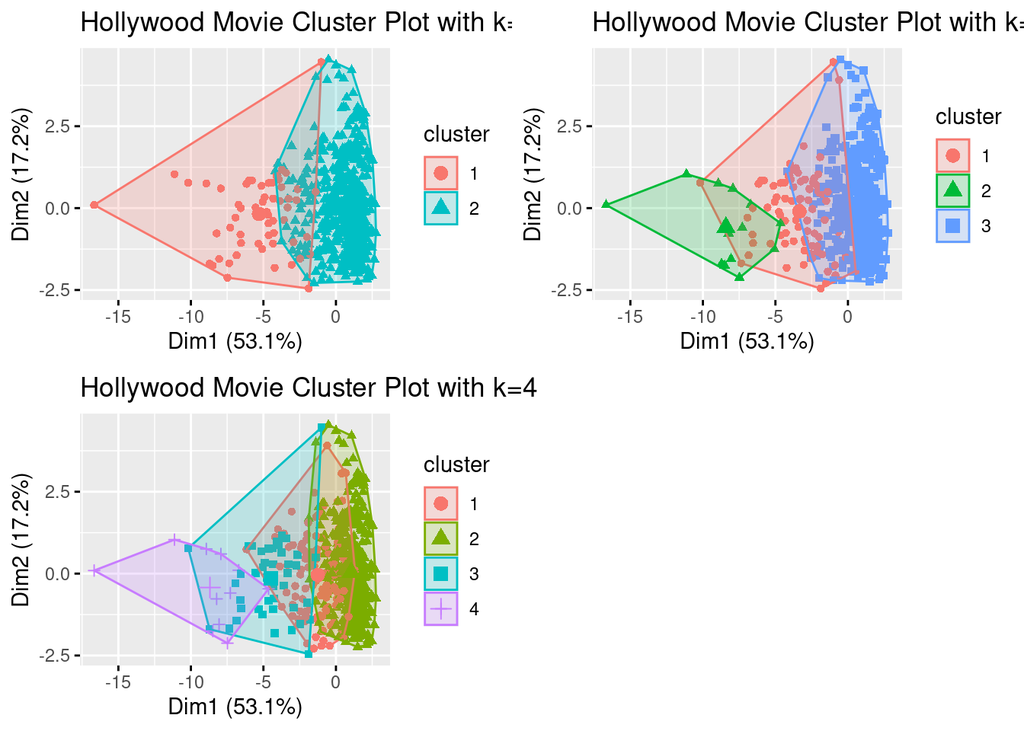

```r
mB2<-fviz_cluster(mcls2, geom = "point", data=movieB)+ggtitle("Hollywood Movie Cluster Plot with k=2")
mB3<-fviz_cluster(mcls3, geom = "point", data=movieB)+ggtitle("Hollywood Movie Cluster Plot with k=3")
mB4<-fviz_cluster(mcls4, geom = "point", data=movieB)+ggtitle("Hollywood Movie Cluster Plot with k=4")

grid.arrange(mB2, mB3, mB4, nrow = 2)
```

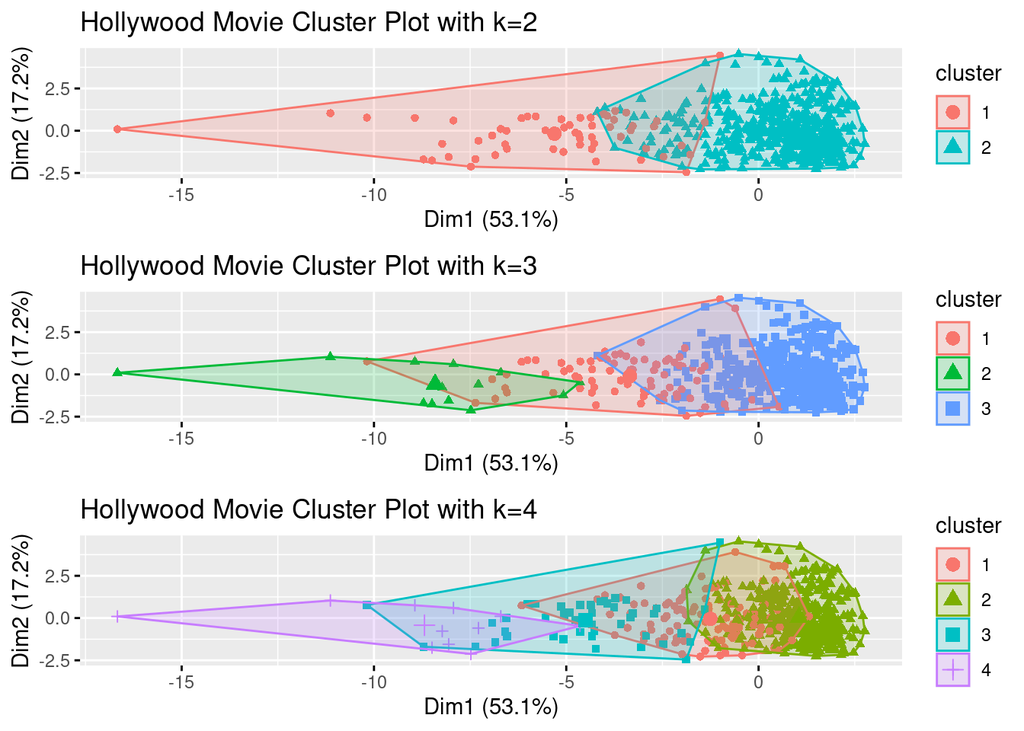

```r
grid.arrange(mB2, mB3, mB4, ncol = 1)
```

As you can see, the clusters in all k-means clustering are overlapped with the other clusters within their graphs. Based on this, `Hollywood Movie Cluster Plot with k=3` and `Hollywood Movie Cluster Plot with k=2` have better clusters than `Hollywood Movie Cluster Plot with k=4` since there is too much overlap to analyze. `Hollywood Movie Cluster Plot with k=3` would be the most optimal since it has more than 2 variables and has less overlap than `Hollywood Movie Cluster Plot with k=4`.

## `Profitability` Column

### Decision Tree `Profitability`

#### With Categorical Variables

This section and the next section are meant to be used as a comparison between the decision trees of `Profitability` that have categorical variables or not.

```r
movie<- movie %>%
  na.omit()
movie
```

| Movie | LeadStudio | RottenTomatoes | AudienceScore | Story | Genre | TheatersOpenWeek | OpeningWeekend | BOAvgOpenWeekend | DomesticGross | ForeignGross | WorldGross | Budget | Profitability | OpenProfit | Year |
| --- | --- | --- | --- | --- | --- | --- | --- | --- | --- | --- | --- | --- | --- | --- | --- |
| Spider-Man 3 | Sony | 61 | 54 | Metamorphosis | Action | 4252 | 151.100 | 35540 | 336.530 | 554.340 | 890.870 | 258.0 | 345.30 | 58.57 | 2007 |
| Shrek the Third | Paramount | 42 | 57 | Quest | Animation | 4122 | 121.600 | 29507 | 322.720 | 476.240 | 798.960 | 160.0 | 499.35 | 76.00 | 2007 |
| Transformers | Paramount | 57 | 89 | Monster Force | Action | 4011 | 70.500 | 17577 | 319.250 | 390.460 | 709.710 | 150.0 | 473.14 | 47.00 | 2007 |
| Pirates of the Caribbean: At World's End | Disney | 45 | 74 | Rescue | Action | 4362 | 114.700 | 26302 | 309.420 | 654.000 | 963.420 | 300.0 | 321.14 | 38.23 | 2007 |
| Harry Potter and the Order of the Phoenix | Warner Bros | 78 | 82 | Quest | Adventure | 4285 | 77.100 | 17998 | 292.000 | 647.880 | 939.890 | 150.0 | 626.59 | 51.40 | 2007 |
| I Am Legend | Warner Bros | 69 | 69 | Quest | Thriller | 3606 | 77.200 | 21411 | 256.390 | 328.960 | 585.350 | 150.0 | 390.23 | 51.47 | 2007 |
| The Bourne Ultimatum | Universal | 93 | 91 | Pursuit | Thriller | 3660 | 69.300 | 18929 | 227.470 | 215.350 | 442.820 | 110.0 | 402.57 | 63.00 | 2007 |
| National Treasure: Book of Secrets | Disney | 31 | 72 | The Riddle | Thriller | 3832 | 44.800 | 11686 | 219.960 | 237.400 | 457.360 | 130.0 | 351.82 | 34.46 | 2007 |
| Alvin and the Chipmunks | Fox | 26 | 73 | Comedy | Animation | 3475 | 44.300 | 12750 | 217.330 | 144.010 | 361.340 | 70.0 | 516.19 | 63.29 | 2007 |
| 300 | Warner Bros | 60 | 90 | Sacrifice | Action | 3103 | 70.900 | 22844 | 210.610 | 245.450 | 456.070 | 65.0 | 701.64 | 109.08 | 2007 |

[output cut: 581 more lines]

The `movie`(`HollywoodMovies` dataset) dataset originally had many NA values in all columns, which needed to be removed. The code above is used to remove NA values with `na.omit()` since it needs to be removed to train the code and create decision and random trees.

```r
HighProfit <- ifelse(movie$Profitability >= 400, "Yes", "No")

movie<-data.frame(movie, HighProfit)

movie$Profitability<-as.factor(movie$Profitability)
```

The code above creates a new variable called `HighProfit` that will be used to determine if a movie has a profit of more than 400 in the `Profitability` column. The `HighProfit` column will be determining this by labeling movies with string values `Yes` or `No` depending on the movie’s profitability.

```r
#remove.packages("Rcpp")
#install.packages('Rcpp')
library(Rcpp)
tree.movieProf<-train(HighProfit ~ . -Profitability, data=movie, method="rpart")
tree.movieProf
```

```
## CART
##
## 591 samples
##  16 predictor
##   2 classes: 'No', 'Yes'
##
## No pre-processing
## Resampling: Bootstrapped (25 reps)
## Summary of sample sizes: 591, 591, 591, 591, 591, 591, ...
## Resampling results across tuning parameters:
##
##   cp          Accuracy   Kappa
##   0.08163265  0.8425314  0.5445023
##   0.14285714  0.8273639  0.4935204
##   0.35374150  0.8092230  0.4007677
##
## Accuracy was used to select the optimal model using the largest value.
## The final value used for the model was cp = 0.08163265.
```

The variable, `HighProfit` was trained with the dataset `movie` (the stored`Hollywood` dataset) and without the variable, `Profitability`. As you can see that there are relatively low `Kappa` scores that suggest that the two raters do have a weak agreement with the two raters when using nominal scores. The most optimal model has an `Accuracy` of 0.8425314, `cp` of 0.08163265, and a `Kappa` of 0.5445023, which is not great because of `Accuracy` being average and the low `Kappa`. This training method used 25 Bootstrapped reps for resampling.

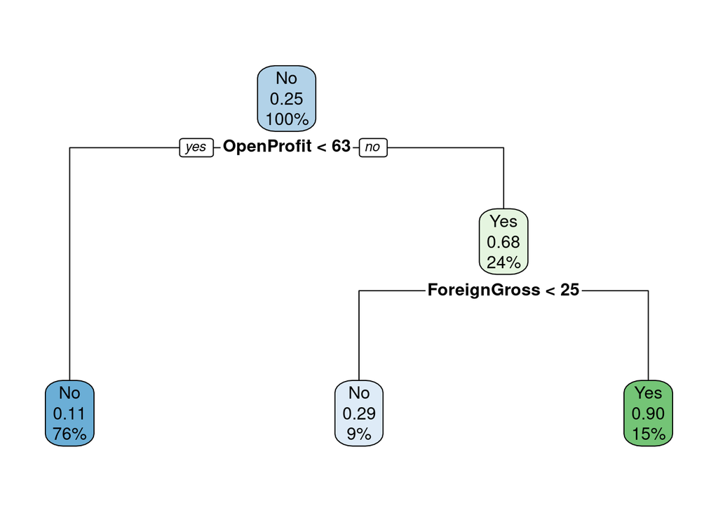

```r
rpart.plot(tree.movieProf$finalModel)
```

For this section, the categorical variable was not removed so that the decision trees with categorical variables and without categorical variables can be compared.

The decision tree with categorical variables has that the root node shows that 25% of movies have high `Profitability` of `more than 400.

> When `OpenProfit` is less than 63, then there 11% of movies have high `Profitability` of more than 400, and 76% of them have an `OpenProit` of less than 63.

> If movies have `OpenProfit` of more than 63 and a Foreign Gross of more than 25 million dollars, then 90% of movies have a `Profitability` of more than 400, and 15% of those movies have a `ForeignGross` of more than 25 million.

This decision tree is somewhat poor since the depth of the decision tree is too small and too few variables to consider. That is why the next section is the same as this section but the decision tree does not include the categorical variables.

These rules can be shown at the bottom.

```r
rpart.rules(tree.movieProf$finalModel)
```

|  | .outcome |  |  |  |  |  |  |  |  |
| --- | --- | --- | --- | --- | --- | --- | --- | --- | --- |
| 2 | 0.11 | when | OpenProfit | < | 63 |  |  |  |  |
| 6 | 0.29 | when | OpenProfit | >= | 63 | & | ForeignGross | < | 25 |
| 7 | 0.90 | when | OpenProfit | >= | 63 | & | ForeignGross | >= | 25 |

#### Removed Categorical Variables

This section and the previous section are meant to be used as a comparison between the decision trees of `Profitability` that have categorical variables or not. This section removes the categorical variables, `Movie` and `LeadStudio`.

```r
movie <- read_csv("https://raw.githubusercontent.com/reisanar/datasets/master/HollywoodMovies.csv")
```

```r
myvars<-c("RottenTomatoes", "AudienceScore", "TheatersOpenWeek", "DomesticGross", "ForeignGross","WorldGross","Budget","Profitability","OpeningWeekend","BOAvgOpenWeekend")
```

```r
movie<-movie[myvars] %>%
  na.omit()

movie<-data.frame(movie)

movie<-movie %>%
  mutate(HighProfit=ifelse(movie$Profitability >= 400, "Yes", "No")) %>%
  dplyr::select(-Profitability)

movie<-movie %>%
  mutate(HighProfit=as.factor(HighProfit))
```

The `movie` dataset originally had many NA values in all columns, which need to be removed. The code above is used to remove NA values with `na.omit()` since it needs to be removed to train the code and create decision and random trees. The code above also creates a new variable called `HighProfit` that will be used to determine if a movie has a profit of more than 400 in the `Profitability` column. The `HighProfit` column will be determining this by labeling movies with string values of `Yes` or `No` depending on the movie’s profitability.

```r
inTrain<-createDataPartition(y=movie$HighProfit, p=0.75, list=FALSE)
train <- movie[inTrain,]
test <- movie[-inTrain,]
```

```r
set.seed(217)
cvcontrol <- trainControl(method = "repeatedcv", number = 10, allowParallel = TRUE)
```

The two chunks above create training and testing sets for the `HighProfit` variable in the dataset, `movie`. The split is needed to train the data in order to better create decision trees. A `trainControl` variable was made to be used on the `train` variable shown at the bottom. The variable, `cvcontril` is made with the `trainControl()` method that uses the method `repeatedcv`, which is `cv` that repeats, 10-folds classification, and allows the code to run parallel.

```r
dt_movie<- train(HighProfit ~ . , data = train, method = "rpart",
                     trControl = cvcontrol, tuneLength = 10)
dt_movie
```

```
## CART
##
## 627 samples
##   9 predictor
##   2 classes: 'No', 'Yes'
##
## No pre-processing
## Resampling: Cross-Validated (10 fold, repeated 1 times)
## Summary of sample sizes: 565, 564, 564, 564, 564, 565, ...
## Resampling results across tuning parameters:
##
##   cp           Accuracy   Kappa
##   0.005882353  0.8611623  0.6275904
##   0.014705882  0.8579621  0.6152119
##   0.026470588  0.8516385  0.6003964
##   0.047058824  0.8340758  0.5565113
##   0.052941176  0.8245520  0.5243331
##   0.058823529  0.7782386  0.3981716
##   0.064705882  0.7782386  0.3981716
##   0.070588235  0.7718638  0.3816776
##   0.094117647  0.7655146  0.3665162
##   0.188235294  0.7400410  0.1125865
##
## Accuracy was used to select the optimal model using the largest value.
## The final value used for the model was cp = 0.005882353.
```

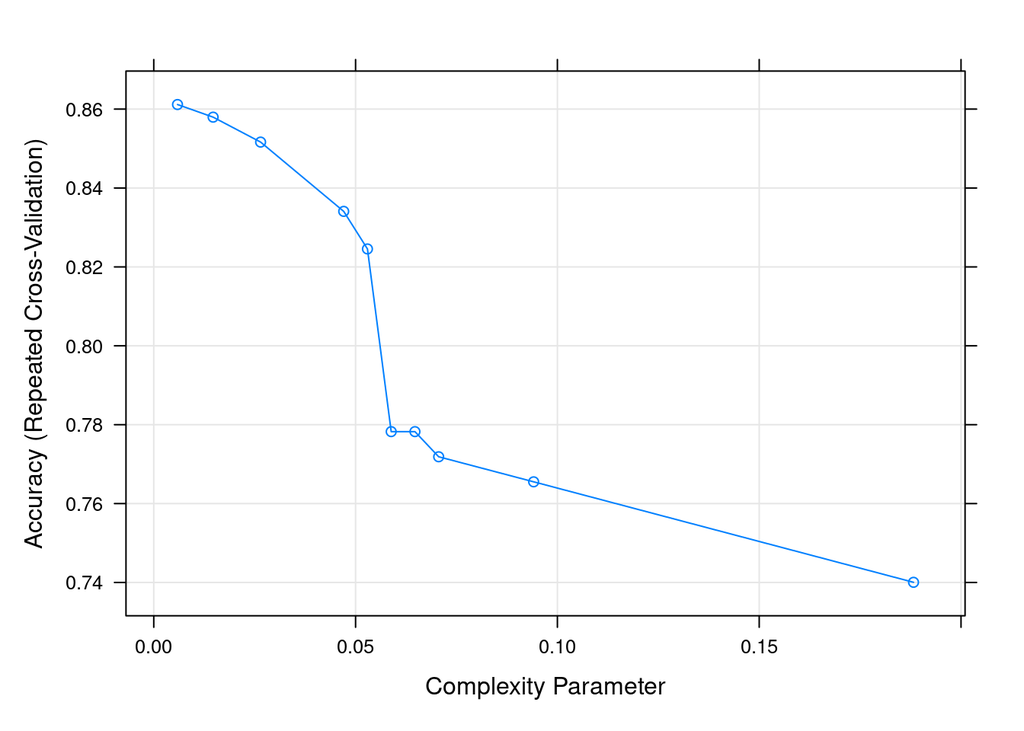

```r
plot(dt_movie)
```

The plot above shows the relationship between the `complexity parameter` and the `Accuracy (Repeated Cross-Validation)`. The graph shows it has a negative relationship. This suggests that as the `complexity parameter` increases, the `accuracy` decreases.

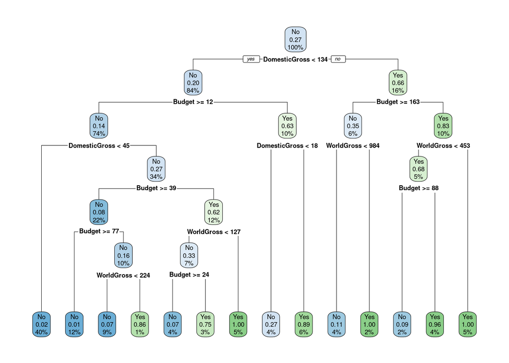

```r
rpart.plot(dt_movie$finalModel)
```

The decision tree shown above does not include categorical variables that would hinder the creation of a precise decision tree. This is a much superior decision tree compared to the previous section since it has more depth than the decision tree with categorical variables.

```r
tree_classTrain<-predict(dt_movie, type="raw")
head(tree_classTrain)
```

```
## [1] No  Yes Yes No  Yes Yes
## Levels: No Yes
```

```r
confusionMatrix(train$HighProfit, tree_classTrain)
```

```
## Confusion Matrix and Statistics
##
##           Reference
## Prediction  No Yes
##        No  447  10
##        Yes  24 146
##
##                Accuracy : 0.9458
##                  95% CI : (0.925, 0.9622)
##     No Information Rate : 0.7512
##     P-Value [Acc > NIR] : < 2e-16
##
##                   Kappa : 0.8592
##
##  Mcnemar's Test P-Value : 0.02578
##
##             Sensitivity : 0.9490
##             Specificity : 0.9359
##          Pos Pred Value : 0.9781
##          Neg Pred Value : 0.8588
##              Prevalence : 0.7512
##          Detection Rate : 0.7129
##    Detection Prevalence : 0.7289
##       Balanced Accuracy : 0.9425
##
##        'Positive' Class : No
##
```

```r
tree_classTest<-predict(dt_movie, newdata=test, type="prob")
tree_classTest
```

|  | No | Yes |
| --- | --- | --- |
| 6 | 0.00000000 | 1.00000000 |
| 7 | 0.90909091 | 0.09090909 |
| 8 | 0.00000000 | 1.00000000 |
| 14 | 0.04347826 | 0.95652174 |
| 16 | 0.90909091 | 0.09090909 |
| 21 | 0.98648649 | 0.01351351 |
| 22 | 0.00000000 | 1.00000000 |
| 23 | 0.98648649 | 0.01351351 |
| 35 | 0.00000000 | 1.00000000 |
| 36 | 0.98648649 | 0.01351351 |

[output cut: 198 more lines]

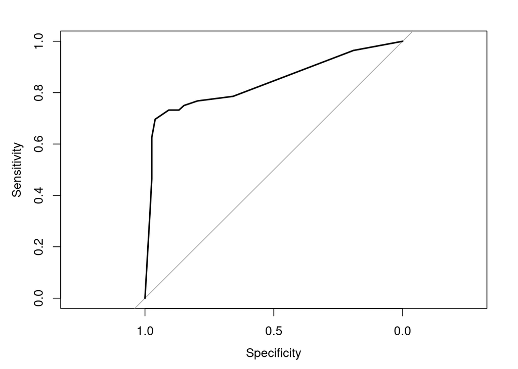

```r
ROC_curve_dt<-roc(test$HighProfit, tree_classTest[,"Yes"])
plot(ROC_curve_dt)
```

```r
auc(ROC_curve_dt)
```

```
## Area under the curve: 0.8392
```

### Bagging

```r
bag_movie<-train(HighProfit~.,data=train, method="treebag", trControl=cvcontrol, importance=TRUE)

bag_movie
```

```
## Bagged CART
##
## 627 samples
##   9 predictor
##   2 classes: 'No', 'Yes'
##
## No pre-processing
## Resampling: Cross-Validated (10 fold, repeated 1 times)
## Summary of sample sizes: 564, 564, 565, 564, 565, 564, ...
## Resampling results:
##
##   Accuracy   Kappa
##   0.9232719  0.7976616
```

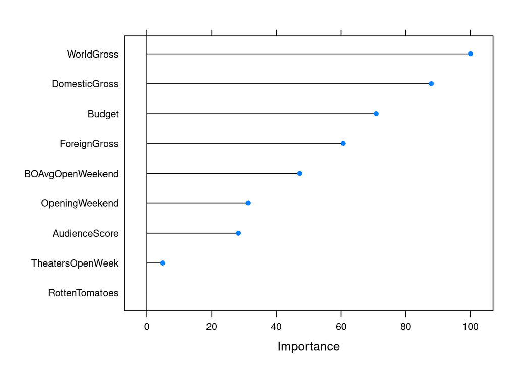

```r
plot(varImp(bag_movie))
```

```r
bagg_pred<-predict(bag_movie, newdata = test, type="raw")
head(bagg_pred)
```

```
## [1] Yes Yes No  Yes No  No
## Levels: No Yes
```

```r
confusionMatrix(test$HighProfit, bagg_pred)
```

```
## Confusion Matrix and Statistics
##
##           Reference
## Prediction  No Yes
##        No  146   6
##        Yes  15  41
##
##                Accuracy : 0.899
##                  95% CI : (0.8498, 0.9364)
##     No Information Rate : 0.774
##     P-Value [Acc > NIR] : 2.25e-06
##
##                   Kappa : 0.7297
##
##  Mcnemar's Test P-Value : 0.08086
##
##             Sensitivity : 0.9068
##             Specificity : 0.8723
##          Pos Pred Value : 0.9605
##          Neg Pred Value : 0.7321
##              Prevalence : 0.7740
##          Detection Rate : 0.7019
##    Detection Prevalence : 0.7308
##       Balanced Accuracy : 0.8896
##
##        'Positive' Class : No
##
```

```r
bagg_probs <- predict(bag_movie, newdata = test, type = "prob")
head(bagg_probs)
```

|  | No | Yes |
| --- | --- | --- |
| 1 | 0.48 | 0.52 |
| 2 | 0.44 | 0.56 |
| 3 | 0.52 | 0.48 |
| 4 | 0.04 | 0.96 |
| 5 | 0.96 | 0.04 |
| 6 | 1.00 | 0.00 |

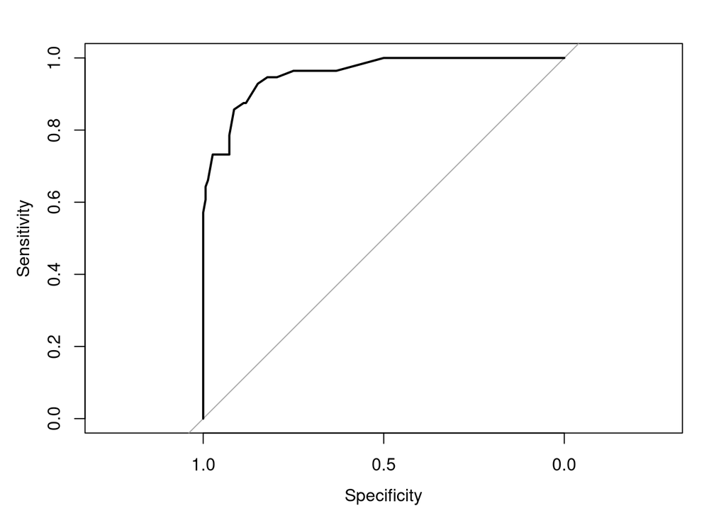

```r
ROC_curve_bagg <- roc(test$HighProfit, bagg_probs[ , "Yes"])
plot(ROC_curve_bagg)
```

```r
auc(ROC_curve_bagg)
```

```
## Area under the curve: 0.9571
```

### Random Forest

```r
rf_HighProfit<-train(HighProfit~., data=train, method="rf", trControl=cvcontrol, importance =TRUE)
rf_HighProfit
```

```
## Random Forest
##
## 627 samples
##   9 predictor
##   2 classes: 'No', 'Yes'
##
## No pre-processing
## Resampling: Cross-Validated (10 fold, repeated 1 times)
## Summary of sample sizes: 564, 565, 564, 564, 564, 565, ...
## Resampling results across tuning parameters:
##
##   mtry  Accuracy   Kappa
##   2     0.9074245  0.7547333
##   5     0.9266769  0.8095847
##   9     0.9346646  0.8298408
##
## Accuracy was used to select the optimal model using the largest value.
## The final value used for the model was mtry = 9.
```

```r
rf_pred<-predict(rf_HighProfit, newdata=test, type="raw")
confusionMatrix(test$HighProfit, rf_pred)
```

```
## Confusion Matrix and Statistics
##
##           Reference
## Prediction  No Yes
##        No  149   3
##        Yes  14  42
##
##                Accuracy : 0.9183
##                  95% CI : (0.8724, 0.9517)
##     No Information Rate : 0.7837
##     P-Value [Acc > NIR] : 1.592e-07
##
##                   Kappa : 0.7786
##
##  Mcnemar's Test P-Value : 0.01529
##
##             Sensitivity : 0.9141
##             Specificity : 0.9333
##          Pos Pred Value : 0.9803
##          Neg Pred Value : 0.7500
##              Prevalence : 0.7837
##          Detection Rate : 0.7163
##    Detection Prevalence : 0.7308
##       Balanced Accuracy : 0.9237
##
##        'Positive' Class : No
##
```

```r
rf_probs<-predict(rf_HighProfit, newdata = test, type = "prob")
head(rf_probs)
```

|  | No | Yes |
| --- | --- | --- |
| 6 | 0.464 | 0.536 |
| 7 | 0.536 | 0.464 |
| 8 | 0.634 | 0.366 |
| 14 | 0.002 | 0.998 |
| 16 | 0.942 | 0.058 |
| 21 | 0.986 | 0.014 |

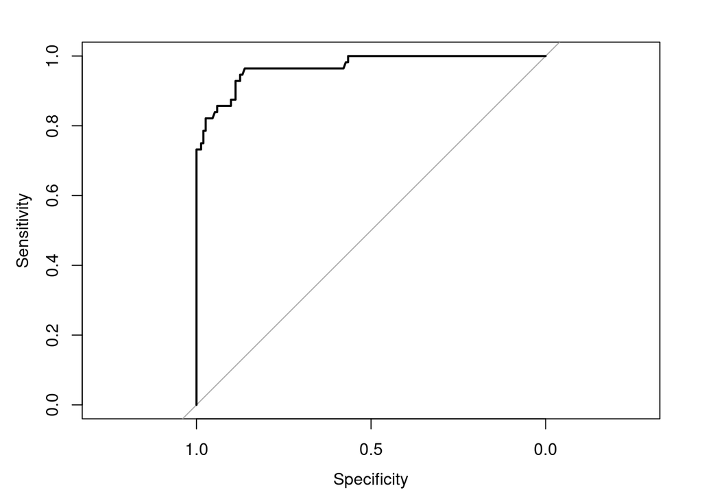

```r
ROC_curve_rf<-roc(test$HighProfit, rf_probs[,"Yes"])
plot(ROC_curve_rf)
```

```r
auc(ROC_curve_rf)
```

```
## Area under the curve: 0.9685
```